DEFINE THAT ✳ / KITCHEN EDITION

FIELD GUIDE № 001 · THE CIRCLE PROBLEM

# Five ways to make *a circle.*

Crêpe. Pancake. Tortilla. Flatbread. Galette. They can look like cousins on a plate. But their real differences begin **before** they hit the pan.

Explore the family ↘

A tiny interactive explainer. No frameworks. No crumbs.

01 / THE BIG REVEAL

## It's not a neat family tree.

The names aren't all at the same level. **Flatbread** describes a broad family of breads. **Tortilla** is one member. **Crêpe** is a kind of thin pancake in the broad sense. **Galette** sometimes names a buckwheat cousin of the crêpe—and sometimes something entirely different.

START WITH THE MIXTURE

### 🥣 Pourable batter

You pour or ladle it onto a hot surface, then spread it or let it settle. The batter sets as it cooks.

Crêpe Very thin; usually no raising agent

Pancake Often thick and raised in North America

Breton galette Usually buckwheat; thin, often savoury

OR START WITH

### 🤲 Shapeable dough

You press, pat, stretch, or roll it *before* cooking. Typical flatbreads belong here.

Flatbread A whole category, not one single recipe

↳ Tortilla Corn masa or wheat flour; pressed or rolled

↳ Roti · naan · pita… Different traditions; some use yeast

**The useful rule:** Ask *“Can I pour this mixture, or must I shape it?”* before asking whether the finished food is round. This is a cooking shortcut, not a rigid scientific taxonomy.

02 / MEET THE FIVE

## Same silhouette. Different logic.

Here are the familiar versions of each. Regional recipes vary—because food is culture, not a database with perfect primary keys.

The flexible sheet

### Crêpe

A thin layer of fluid batter that cooks into a soft, foldable sheet.

Batter · thin

**Typical base**

Wheat flour, eggs, milk or water

**The move**

Pour → spread or swirl

The fluffy one*

### Pancake

North American-style pancakes rise into little soft cakes on a griddle.

Batter · often raised

**Typical base**

Wheat flour, dairy, egg, baking powder

**The move**

Ladle → let spread → flip

The pressed or rolled one

### Tortilla

A Mexican and Central American flatbread, often wrapped around food.

Dough · flatbread

**Typical base**

Nixtamalized corn masa or wheat flour

**The move**

Press or roll → comal

The umbrella category

### Flatbread

Not one dish: many thin-ish breads from different culinary traditions.

Usually dough

**Typical base**

Varies: wheat and other grains

**The move**

Roll or stretch → griddle or bake

The buckwheat cousin

### Galette

In Brittany, a thin buckwheat preparation, often folded around a savoury filling.

Batter · buckwheat

**Typical base**

Buckwheat flour, water, salt

**The move**

Pour → spread → fold

* “Pancake” means different things around the world. British pancakes can be thin; crêpes are also pancakes in the broad culinary sense. “Galette” can also mean a free-form tart or other French baked goods.

03 / THE COMPARISON LAB

## Put two on the griddle.

Pick any pair. What changes? The ingredients, the method, or just the name?

First food

vs

Second food

QUICK REFERENCE · TAP A LENS

| Food | Mixture | Typical grain | Leavening | Shape / cook |
| --- | --- | --- | --- | --- |
| Crêpe | Thin batter | Wheat | Usually none | Spread or swirl on pan |
| Pancake* | Thicker batter | Usually wheat | Often baking powder / soda | Ladle and flip |
| Tortilla | Shapeable dough | Corn masa or wheat | Usually none | Press / roll; cook on comal |
| Flatbread | Usually dough | Varies | Sometimes yeast; sometimes none | Roll / stretch; griddle or bake |
| Breton galette | Thin batter | Buckwheat | Usually none | Spread; fold with filling |

* “Pancake” in this table means the familiar North American fluffy style. Every cell describes a typical version, not a universal rule.

04 / THE MINI CHALLENGE

## Can you name it without seeing it?

ROUND 1 / 5

Score: 0

05 / THE COUNTERTOP TEST

## The no-sugar surprise.

No sugar, but still a *crêpe.* Why?

Because sweetness isn't the defining feature. A classic crêpe can be sweet or savoury. What matters more is a **fluid batter spread into a thin sheet**—not a ball of dough pressed or rolled flat.

**Field sample:** A Proctor Silex crêpe made with flour, milk, eggs, butter and salt. No sugar, no raising agent, spread very thin. Classification: **crêpe**. Verdict: delicious-looking evidence. 🥞

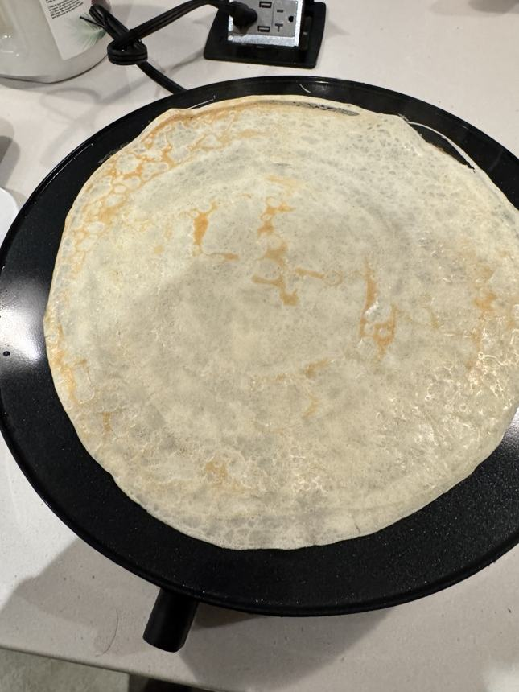

Evidence from the kitchen · sample 001

## Notes from the kitchen library

This is a practical cooking map, not a claim that culinary traditions fit into rigid categories. Definitions vary by place, language, and recipe.

- [France.fr — Breton crêpes and buckwheat galettes ↗](https://www.france.fr/en/article/all-you-need-to-know-about-breton-crepes-in-5-minutes/)
- [King Arthur Baking — Parisian-style crêpes ↗](https://www.kingarthurbaking.com/recipes/parisian-street-vendor-crepes-recipe)
- [Baking Industry Research Trust — Flatbread varieties ↗](https://www.bakeinfo.co.nz/facts/bread/types-of-bread/flat-breads/)
- [Smithsonian — Nixtamalization and corn tortillas ↗](https://americanhistory.si.edu/sites/default/files/file-uploader/CUH%20092019%20Nixtamalization%20and%20Corn%20Tortillas.pdf)
- [Smithsonian Magazine — A brief history of pancakes ↗](https://www.smithsonianmag.com/history/a-brief-history-of-pancakes-180981667/)
- [The Kitchn — The many meanings of “galette” ↗](https://www.thekitchn.com/what-is-galette-23457970)